# BL40A2010 Introduction to IoT-Based Systems

## Assignment 1, 08.09.2023

### Author: Martyna Pitera

**(1) Analyze an electric heater as a system following Example 1.1.**

Answer: Peculiar operation: Heat the air in room or home Conditions of production: Machine which converts electrical energy to heat energy Conditions of reproduction: Connection to electricity, working cable and socket External conditions: Factories that are producing electric heaters

**(2) Give one example for each scientific rationalities presented in Section 1.2.1 similar to Example 1.2.**

Answer: Climate change and global warming. Classical: We can see that climate changes, there is more natural disasters, temperatures are higher during the year Non-classical: Scientists are making mathematical models to estimate how and when will temperature among the world increase, they can also estimate how people can stop the process of global warming Interventionist: Designing a plan of stopping the global warming and implement it

**(3) Download the air temperature data of one year from [FMI](http://en.ilmatieteenlaitos.fi/download-observations#!/) at the city/region you currently live. Make four (arbitrary) time series plots for one year, one month, one week and one day. Besides, for each one of these time series, compute the average temperature, and plot it in the respective plot as a constant line.**

*Hint:* Code like in the tutorial notebook.

```
<class 'pandas.core.series.Series'>
DatetimeIndex: 6068 entries, 2021-01-01 00:00:00 to 2021-12-31 10:00:00
Series name: Air temperature (degC)
Non-Null Count  Dtype
--------------  -----
6068 non-null   float64
dtypes: float64(1)
memory usage: 94.8 KB
```

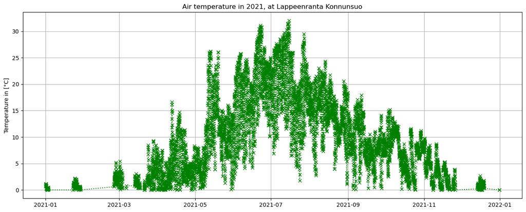

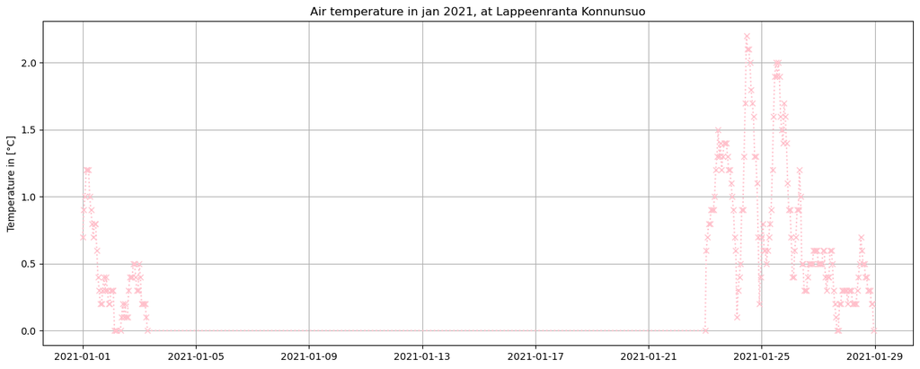

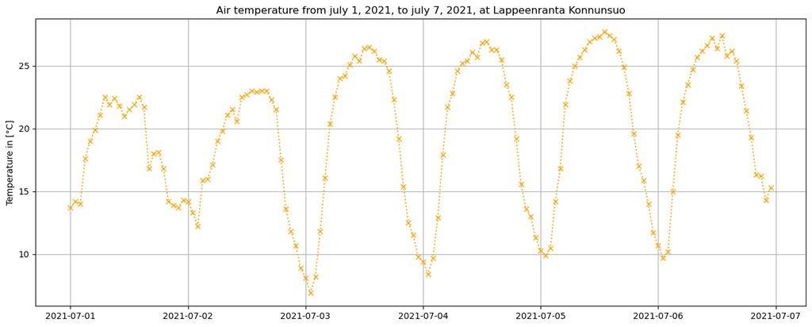

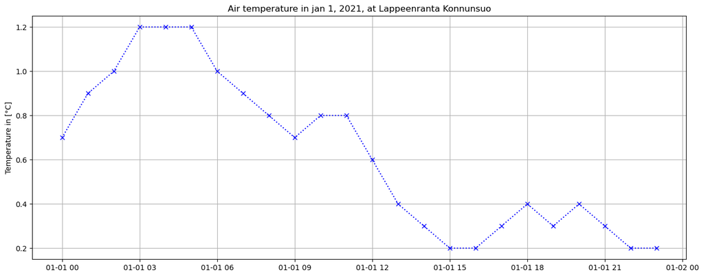

```
<class 'pandas.core.series.Series'>
DatetimeIndex: 6068 entries, 2021-01-01 00:00:00 to 2021-12-31 10:00:00
Series name: Air temperature (degC)
Non-Null Count  Dtype
--------------  -----
6068 non-null   float64
dtypes: float64(1)
memory usage: 94.8 KB
```

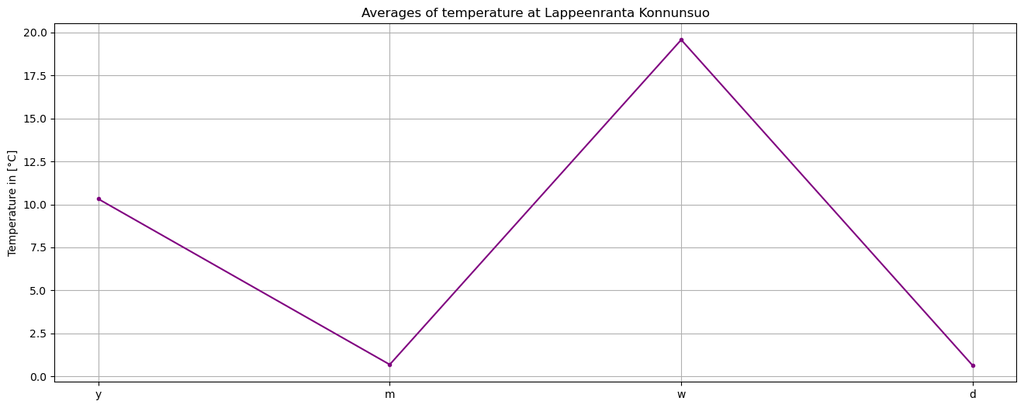

```python
#pip install -r requirements.txt

import pandas as pd
import matplotlib.pyplot as plt
import numpy as np

Temperature = pd.read_csv("temp.csv",dayfirst=True,sep=",",
                          header=0,decimal=b".",index_col=0,
                          parse_dates= [[0, 1, 2, 3]],usecols=[0,1,2,3,5])

Temperature = Temperature[~Temperature['Air temperature (degC)'].str.contains("-")] ;
Temperature = Temperature['Air temperature (degC)'].astype(float)

Temperature.head()
Temperature.info()

#PLOTTING
#one year
year = Temperature['2021']
plt.figure(figsize=(16,6))
plt.plot(year,color='green', marker='x',linestyle=':')
plt.title("Air temperature in 2021, at Lappeenranta Konnunsuo")
plt.ylabel("Temperature in [°C]")
plt.grid(True)
plt.show()

#one month
month = Temperature['2021-1']
plt.figure(figsize=(16,6))
plt.plot(month,color='pink', marker='x',linestyle=':')
plt.title("Air temperature in jan 2021, at Lappeenranta Konnunsuo")
plt.ylabel("Temperature in [°C]")
plt.grid(True)
plt.show()

#one week
#at the beggining I wanted to take temperatures from '2021-1-6':'2021-1-7', but it is empty since I've already deleted data with "-"
week = Temperature['2021-7-1':'2021-7-6'] #I've chosen 2021-7-6 because it actually shows plot to 2021-7-7 so one week
plt.figure(figsize=(16,6))
plt.plot(week,color='orange', marker='x',linestyle=':')
plt.title("Air temperature from july 1, 2021, to july 7, 2021, at Lappeenranta Konnunsuo")
plt.ylabel("Temperature in [°C]")
plt.grid(True)
plt.show()

#one day
day = Temperature['2021-1-1']
plt.figure(figsize=(16,6))
plt.plot(day,color='blue', marker='x',linestyle=':')
plt.title("Air temperature in jan 1, 2021, at Lappeenranta Konnunsuo")
plt.ylabel("Temperature in [°C]")
plt.grid(True)
plt.show()

#AVERAGE TEMPERATURES
year.info()
y = year.mean()
m = month.mean()
w = week.mean()
d = day.mean()

a = [y,m,w,d]
plt.figure(figsize=(16,6))
plt.plot(a, color='purple', marker='.',linestyle='-')
plt.title("Averages of temperature at Lappeenranta Konnunsuo")
plt.ylabel("Temperature in [°C]")
plt.xticks([0.0, 1.0, 2.0, 3.0], ['y', 'm', 'w', 'd'])
plt.grid(True)
plt.show()
```

**(4) Consider a house with an electric heater. How the electricity consumption of the heater would be affected by the outside air temperature? Discuss about 3 current heating methods and their differences.**

Answer: Outside air temperature affect electricity consumption of the heater very much. The bigger is difference between temperatures inside and outside, the more electricity will the heater use to keep the temperature inside.

One method is heating with coal, in my country it used to be the most popular way, but now coal is more expensive and also it isn't eco-friendy, so it is changing. Big downside of this is that you need to use your hands everytime when you want to have warmth in home.

Natural gas heating is said to be eco-friendly, it gives the ability to adjust the temperature and it's comfortable, the computer is controlling the temperature.

Heat pump heating; air source heat pump is appreciated for its nearly maintenance-free system operation and lack of harmful emissions. Some energy is obtained from renewable sources so it isn't expensive in normal using, but is expensive to install it at the beginning.